# Genome_assembly_pipeline | 08.20.2021

The following genome assembly pipline reflects our genome assembly of Aphanomyces cochlioides using DNA sequence reads generated with Oxford Nanopore Technologies and Illumina sequencing, and RNA sequence reads generated with Illumina. Aphanomyces cochlioides is the causal agent of Aphanomyces damping-off and Aphanomyces root rot of sugar beet and spinach.

## Project Outline

1. Get data
2. Uncompress files
3. Combine reads
4. Filter sequences
5. Concatenate filtered reads
6. Genome size estimation
7. Canu assemblies
8. Flye assemblies
9. Contig removal
10. Racon
11. Medaka
12. Pilon
13. QC assembly
14. Annotate repeats
15. Annotate genes
16. Effector search

## 1. Get data

Nanopore long read data was generated from Aphanomyces cochlioides isolate 103-1 and uploaded to MSI.

## 2. Uncompress files

These are commands to uncompress the fastq_pass.tar files. 4 sequencing runs were done at the genomics center.

```bash
1. Upload reads with rsync
#command
tar -xvf /home/hirschc3/botki009/ont_1/fastq_pass.tar
tar -xvf /home/hirschc3/botki009/ont_2/fastq_pass.tar
tar -xvf /home/hirschc3/botki009/ont_3/fastq_pass.tar
tar -xvf /home/hirschc3/botki009/ont_4/fastq_pass.tar

Check md5 numbers to ensure full transfer.
```

## 3. Combine reads

Combine all long-reads

```bash
#concatenate all run 1 files into one file in scratch ont_data
cat /home/hirschc3/botki009/ont_1/fastq_pass/FAL71534_pass_25bd4b92_* > /scratch.global/botki009/ont_data/FAL71534_pass_25bd4b92_all.fastq.gz

cat /home/hirschc3/botki009/ont_1/fastq_pass/FAL71534_pass_c4494750_* > /scratch.global/botki009/ont_data/FAL71534_pass_c4494750_all.fastq.gz

cat /home/hirschc3/botki009/ont_1/fastq_pass/FAN59126_pass_e7054b6c_* > /scratch.global/botki009/ont_data/FAN59126_pass_e7054b6c_all.fastq.gz

cat /home/hirschc3/botki009/ont_1/fastq_pass/FAN61937_pass_8ccbb43d_* > /scratch.global/botki009/ont_data/FAN61937_pass_8ccbb43d_all.fastq.gz

#files saved in /scratch.global/botki009/ont_data
-rw-------. 1 botki009 hirschc3 787M Sep 24 13:43 FAL71534_pass_c4494750_all.fastq.gz
-rw-------. 1 botki009 hirschc3 3.0G Sep 24 13:38 FAL71534_pass_25bd4b92_all.fastq.gz
-rw-------. 1 botki009 hirschc3 9.7G Sep 24 13:50 FAN59126_pass_e7054b6c_all.fastq.gz
-rw-------. 1 botki009 hirschc3  12G Sep 24 13:54 FAN61937_pass_8ccbb43d_all.fastq.gz

#Later we used the cat command to combine all the reads into one file, rather than keeping the 4 sequencing runs separate.
```

### NanoPlot

Metrics for long-read sequence data

```bash
#files
-rw-------. 1 botki009 hirschc3 787M Sep 24 13:43 FAL71534_pass_c4494750_all.fastq.gz
-rw-------. 1 botki009 hirschc3 3.0G Sep 24 13:38 FAL71534_pass_25bd4b92_all.fastq.gz
-rw-------. 1 botki009 hirschc3 9.7G Sep 24 13:50 FAN59126_pass_e7054b6c_all.fastq.gz
-rw-------. 1 botki009 hirschc3  12G Sep 24 13:54 FAN61937_pass_8ccbb43d_all.fastq.gz
############################################################################

#Run NanoPlot (ran command in /scratch.global/botki009/plot_ont)
~/.local/bin/NanoPlot --fastq /scratch.global/botki009/ont_data/FAL71534_pass_25bd4b92_all.fastq.gz

#Ouput:
General summary:
Mean read length:                4,780.4
Mean read quality:                   8.6
Median read length:              2,091.0
Median read quality:                 8.6
Number of reads:               560,271.0
Read length N50:                11,919.0
Total bases:             2,678,292,041.0
Number, percentage and megabases of reads above quality cutoffs
>Q5:    560271 (100.0%) 2678.3Mb
>Q7:    490143 (87.5%) 2359.5Mb
>Q10:   81667 (14.6%) 399.8Mb
>Q12:   780 (0.1%) 2.2Mb
>Q15:   0 (0.0%) 0.0Mb
Top 5 highest mean basecall quality scores and their read lengths
1:  13.6 (129)
2:  13.5 (1697)
3:  13.4 (1216)
4:  13.2 (1612)
5:  13.2 (1193)
Top 5 longest reads and their mean basecall quality score
1:  100772 (8.8)
2:  92919 (6.9)
3:  89856 (8.4)
4:  88411 (10.5)
5:  88390 (8.1)
############################################################################

#Run NanoPlot
~/.local/bin/NanoPlot --fastq /scratch.global/botki009/ont_data/FAL71534_pass_c4494750_all.fastq.gz

#Output:
General summary:
Mean read length:               3,928.5
Mean read quality:                  8.5
Median read length:             1,911.0
Median read quality:                8.5
Number of reads:              177,284.0
Read length N50:                8,035.0
Total bases:              696,463,629.0
Number, percentage and megabases of reads above quality cutoffs
>Q5:    177284 (100.0%) 696.5Mb
>Q7:    151730 (85.6%) 602.1Mb
>Q10:   22310 (12.6%) 90.4Mb
>Q12:   199 (0.1%) 0.4Mb
>Q15:   0 (0.0%) 0.0Mb
Top 5 highest mean basecall quality scores and their read lengths
1:  13.2 (1488)
2:  13.2 (873)
3:  13.2 (934)
4:  13.1 (1587)
5:  13.0 (1361)
Top 5 longest reads and their mean basecall quality score
1:  88935 (6.5)
2:  80853 (7.1)
3:  65772 (6.4)
4:  64830 (8.8)
5:  63456 (7.6)
############################################################################

#Run NanoPlot
submitted as job in home space /home/hirschc3/botki009/
~/.local/bin/NanoPlot --fastq /scratch.global/botki009/ont_data/FAN59126_pass_e7054b6c_all.fastq.gz

#Output:
General summary:
Mean read length:                4,217.4
Mean read quality:                  10.8
Median read length:              2,010.0
Median read quality:                10.9
Number of reads:             2,306,580.0
Read length N50:                 9,560.0
Total bases:             9,727,864,430.0
Number, percentage and megabases of reads above quality cutoffs
>Q5:    2306580 (100.0%) 9727.9Mb
>Q7:    2304169 (99.9%) 9723.3Mb
>Q10:   1438425 (62.4%) 6314.7Mb
>Q12:   770453 (33.4%) 3612.9Mb
>Q15:   34798 (1.5%) 117.9Mb
Top 5 highest mean basecall quality scores and their read lengths
1:  25.0 (1)
2:  22.0 (1)
3:  22.0 (1)
4:  21.0 (1)
5:  21.0 (1)
Top 5 longest reads and their mean basecall quality score
1:  349045 (11.7)
2:  234998 (7.7)
3:  234482 (11.6)
4:  234266 (8.1)
5:  221703 (9.0)
############################################################################

#Run NanoPlot
submitted as job in home space /scratch.global/botki009/
~/.local/bin/NanoPlot --fastq /scratch.global/botki009/ont_data/FAN61937_pass_8ccbb43d_all.fastq.gz

#output
General summary:
Mean read length:                 6,187.1
Mean read quality:                   11.0
Median read length:               2,926.0
Median read quality:                 11.2
Number of reads:              1,826,642.0
Read length N50:                 13,253.0
Total bases:             11,301,555,507.0
Number, percentage and megabases of reads above quality cutoffs
>Q5:    1826642 (100.0%) 11301.6Mb
>Q7:    1825118 (99.9%) 11296.7Mb
>Q10:   1227616 (67.2%) 7852.3Mb
>Q12:   652922 (35.7%) 4356.0Mb
>Q15:   18038 (1.0%) 82.2Mb
Top 5 highest mean basecall quality scores and their read lengths
1:  23.0 (1)
2:  21.5 (207)
3:  20.9 (1798)
4:  20.0 (1443)
5:  20.0 (1)
Top 5 longest reads and their mean basecall quality score
1:  195392 (7.3)
2:  170977 (8.5)
3:  158967 (10.2)
4:  113652 (11.3)
5:  111551 (9.7)
```

## 4. Filter sequences

Remove low quality and short reads.

```bash
#filter
run nanofilt a few levels of filtering, qual 10 len 1000 and 2000, q 8 l 1000 and 2000 for all long-reads

#save filtered data at
/scratch.global/botki009/filter_ont/

#nanofilt
Installed nanofilt to /home/hirschc3/botki009/.local/bin and /home/hirschc3/botki009/software

#made dir for ont seq summary (for quality filter) 4 files were transfered
/home/hirschc3/botki009/ont_summary
```

### NanoFilt.sh (q 8 l 2000)

filter nanopore data with minimum quality=8 and minimum length=2000

```bash
#!/bin/bash -l
#PBS -l walltime=06:00:00,nodes=1:ppn=2,mem=2gb
#PBS -o /scratch.global/botki009/e_o_files/nanofilt_8_2000o
#PBS -e /scratch.global/botki009/e_o_files/nanofilt_8_2000e
#PBS -N nanofilt.sh

# qsub -t 1-4 -v LIST=ont_4run_list.txt  nanofilt.sh

#location of list file
cd /home/hirschc3/botki009/ont_1/fastq_pass

ISOLATE="$(/bin/sed -n ${PBS_ARRAYID}p ${LIST} | cut -f 1)"

gunzip -c /scratch.global/botki009/ont_data/${ISOLATE}.fastq.gz | ~/.local/bin/NanoFilt -q 8 -l 2000 | gzip > /scratch.global/botki009/filter_ont/${ISOLATE}_q8_l2000.fastq.gz
```

### NanoPlot

Get read metrics for filtered reads (q 8 l 2000).

```bash
# Run NanoPlot
~/.local/bin/NanoPlot --fastq /scratch.global/botki009/filter_ont/FAL71534_pass_25bd4b92_all_q8_l2000.fastq.gz

#output:
General summary:
Mean read length:                8,012.4
Mean read quality:                   9.3
Median read length:              4,248.0
Median read quality:                 9.3
Number of reads:               196,252.0
Read length N50:                14,786.0
Total bases:             1,572,440,922.0
Number, percentage and megabases of reads above quality cutoffs
>Q5:    196252 (100.0%) 1572.4Mb
>Q7:    196252 (100.0%) 1572.4Mb
>Q10:   44084 (22.5%) 349.4Mb
>Q12:   280 (0.1%) 1.6Mb
>Q15:   0 (0.0%) 0.0Mb
Top 5 highest mean basecall quality scores and their read lengths
1:  13.2 (2368)
2:  13.1 (3288)
3:  13.1 (4802)
4:  12.9 (8577)
5:  12.9 (7097)
Top 5 longest reads and their mean basecall quality score
1:  100772 (8.8)
2:  89856 (8.4)
3:  88411 (10.5)
4:  88390 (8.1)
5:  83436 (9.4)

# Run NanoPlot
~/.local/bin/NanoPlot --fastq /scratch.global/botki009/filter_ont/FAL71534_pass_c4494750_all_q8_l2000.fastq.gz

#output:
General summary:
Mean read length:               6,893.1
Mean read quality:                  9.3
Median read length:             3,778.0
Median read quality:                9.2
Number of reads:               53,328.0
Read length N50:               11,878.0
Total bases:              367,595,850.0
Number, percentage and megabases of reads above quality cutoffs
>Q5:    53328 (100.0%) 367.6Mb
>Q7:    53328 (100.0%) 367.6Mb
>Q10:   11036 (20.7%) 75.4Mb
>Q12:   53 (0.1%) 0.2Mb
>Q15:   0 (0.0%) 0.0Mb
Top 5 highest mean basecall quality scores and their read lengths
1:  13.0 (2399)
2:  12.5 (3395)
3:  12.5 (3377)
4:  12.5 (2043)
5:  12.5 (2676)
Top 5 longest reads and their mean basecall quality score
1:  64830 (8.8)
2:  62748 (9.3)
3:  60029 (9.8)
4:  58290 (8.1)
5:  56768 (10.1)

# Run NanoPlot
~/.local/bin/NanoPlot --fastq /scratch.global/botki009/filter_ont/FAN59126_pass_e7054b6c_all_q8_l2000.fastq.gz

#output:
General summary:
Mean read length:                7,298.1
Mean read quality:                  11.4
Median read length:              3,856.0
Median read quality:                11.4
Number of reads:             1,032,508.0
Read length N50:                13,089.0
Total bases:             7,535,395,245.0
Number, percentage and megabases of reads above quality cutoffs
>Q5:    1032508 (100.0%) 7535.4Mb
>Q7:    1032508 (100.0%) 7535.4Mb
>Q10:   741052 (71.8%) 5486.3Mb
>Q12:   417429 (40.4%) 3175.5Mb
>Q15:   15542 (1.5%) 94.8Mb
Top 5 highest mean basecall quality scores and their read lengths
1:  18.3 (2926)
2:  18.3 (2224)
3:  18.2 (2031)
4:  18.2 (3667)
5:  18.2 (2024)
Top 5 longest reads and their mean basecall quality score
1:  349045 (11.7)
2:  234482 (11.6)
3:  234266 (8.1)
4:  221703 (9.0)
5:  220196 (10.9)

# Run NanoPlot
~/.local/bin/NanoPlot --fastq /scratch.global/botki009/filter_ont/FAN61937_pass_8ccbb43d_all_q8_l2000.fastq.gz

#output
General summary:
Mean read length:                8,581.7
Mean read quality:                  11.4
Median read length:              5,086.0
Median read quality:                11.6
Number of reads:             1,118,482.0
Read length N50:                14,422.0
Total bases:             9,598,454,409.0
Number, percentage and megabases of reads above quality cutoffs
>Q5:    1118482 (100.0%) 9598.5Mb
>Q7:    1118482 (100.0%) 9598.5Mb
>Q10:   843180 (75.4%) 7322.0Mb
>Q12:   462124 (41.3%) 4086.1Mb
>Q15:   10563 (0.9%) 72.0Mb
Top 5 highest mean basecall quality scores and their read lengths
1:  18.4 (5431)
2:  18.4 (2230)
3:  18.3 (3077)
4:  18.3 (2171)
5:  18.2 (2199)
Top 5 longest reads and their mean basecall quality score
1:  170977 (8.5)
2:  158967 (10.2)
3:  113652 (11.3)
4:  111551 (9.7)
5:  111486 (12.1)
```

## 5. Concatenate filtered reads

Concatenate filtered long-reads into one file.

```bash
#concatenate the 4 runs that were filtered at min quality 8 min length 2000
cat /scratch.global/botki009/filter_ont/FA*all_q8_l2000.fastq.gz > /scratch.global/botki009/ont_data/all_4_runs_filt_q8_l2000.fastq.gz
```

## 6. Genome size estimation

GUIDE: https://bioinformatics.uconn.edu/genome-size-estimation-tutorial/

### Trimmomatic

Upload Illumina reads, and filter out bad quality data. These reads are used to estimate genome size.

```bash
#filter phred score 25 and above, and min read length 50

#!/bin/bash -l
#PBS -l walltime=8:00:00,nodes=1:ppn=16,mem=20gb
#PBS -m abe
#PBS -o /scratch.global/botki009/e_o_files/trim2_o_file
#PBS -e /scratch.global/botki009/e_o_files/trim2_e_file
#PBS -N trimmomatic2.sh

#qsub -t 1-5 -v LIST=trim_samples.txt trimmomatic2.sh

module load trimmomatic/0.33

cd /scratch.global/botki009/

ISOLATE="$(/bin/sed -n ${PBS_ARRAYID}p ${LIST} | cut -f 1)"

java -jar $TRIMMOMATIC/trimmomatic.jar PE -phred33 -threads 16 -trimlog /scratch.global/botki009/trimmomatic/${ISOLATE}_trimlog.txt /home/hirschc3/botki009/AC_sequencing/Forward_reads/${ISOLATE}_R1_001.fastq.gz /home/hirschc3/botki009/AC_sequencing/Reverse_reads/${ISOLATE}_R2_001.fastq.gz /scratch.global/botki009/trimmomatic/${ISOLATE}_f_paired_q25.fastq.gz /scratch.global/botki009/trimmomatic/${ISOLATE}_f_unparied_q25.fastq.gz /scratch.global/botki009/trimmomatic/${ISOLATE}_r_paired_q25.fastq.gz /scratch.global/botki009/trimmomatic/${ISOLATE}_r_unpaired_q25.fastq.gz LEADING:10 TRAILING:10 SLIDINGWINDOW:4:25 ILLUMINACLIP:/scratch.global/botki009/adapter_file_fixed.txt:2:30:10:2:keepBothReads MINLEN:50

#output in
/scratch.global/botki009/trimmomatic


#concatenate all 5 isolates forward and reverse paired illumina reads
cat /scratch.global/botki009/trimmomatic/*paired_q25.fastq.gz > /scratch.global/botki009/trimmomatic/5_iso_paired_q25.fastq.gz
#output
/scratch.global/botki009/trimmomatic  18G Nov 11 12:50 5_iso_paired_q25.fastq.gz
```

### jellyfish

Estimate genome size from the k-mer distribution in the illumina data.

```bash
#!/bin/bash -l
#PBS -l walltime=24:00:00,nodes=1:ppn=14,mem=20gb
#PBS -m abe
#PBS -o /scratch.global/botki009/e_o_files/jellyfish2.o
#PBS -e /scratch.global/botki009/e_o_files/jellyfish2.e
#PBS -N jellyfish.sh

# qsub /scratch.global/botki009/jellyfish.sh


module load jellyfish/2.1.3

jellyfish count -m 21 -s 100M -t 14 -C /scratch.global/botki009/trimmomatic/5_iso_paired_q25.fastq

# get histogram data
jellyfish histo -o 5_iso_paired_q25.histo 5_iso_paired_q25
```

This was part run in R, using the k-mer histogram output from Jellyfish, to calcualte the genome size estimation.

```r
#13-35_forward_reverse_q25
#Estimate A.cochlioides genome size using 21-mer histogram from (F&R)paired Illumina reads for 13-35 isolates, quality =25+

#get data into R
kmer_hist_1335<-read.table(file="/Users/jakebotkin/Desktop/ac_genome_assembly_work/13-35_for_rev_paired_q25.histo",header = FALSE)

#plot initial histogram
plot(kmer_hist_1335[1:800,], type="l")

#remove first 16 rows in data frame
kmer_hist_1335_sub<-kmer_hist_1335[-c(1:20), ]

#replot hist
plot(kmer_hist_1335_sub[1:300,], type="l")

#plot points on hist line (data points from 2 through 100)
points(kmer_hist_1335_sub[10:300,])

#calculate the total k-mers in the distribution
sum(as.numeric(kmer_hist_1335_sub[1:9975,1]*kmer_hist_1335_sub[1:9975,2]))

#understanding brackets
#[row , column]
#[1:9975,1]- select the first column of rows 1 through 9975
#[1:9975,2]-select the second column of rows 1 through 9975
#column 1= X axis = freq kmer observed
#column 2= Y axis = number of kmers at a give freq

#determine peak (manually)
kmer_hist_1335_sub[30:150, ]
#peak = 72  72 1093439

#summary of kmer dist
summary(kmer_hist_1335_sub)

#identify the peak point (automatically)
kmer_hist_1335_sub[which.max(kmer_hist_1335_sub$V2),]

#genome size estimate
sum(as.numeric(kmer_hist_1335_sub[1:9975,1]*kmer_hist_1335_sub[1:9975,2]))/72
```

## 7. Canu assemblies

Canu is a Celera assembler for de novo WGS assemblies of DNA sequence data.

### canu.sh

(canu assembly #3 = A3) Assemble nanopore long-reads with Canu.

```bash
#!/bin/bash
#SBATCH -N 1
#SBATCH -n 40
#SBATCH --time=1:00:00
#SBATCH -o /scratch.global/botki009/e_o_files/canu_fast_sbatch_assemble.o
#SBATCH -e /scratch.global/botki009/e_o_files/canu_fast_sbatch_assemble.e
#SBATCH --job-name=canu_fast_sbatch_assemble.sh
#SBATCH --mem=128G

#sbatch canu_fast_sbatch_assemble.sh

module load java/openjdk-8_202

/home/hirschc3/botki009/software/canu-2.1/bin/canu 'useGrid=false' -p ac_ont_q8_l2000_assemble -d /scratch.global/botki009/ac_ont5/assemble_only 'genomeSize=82m' 'correctedErrorRate=0.1' 'minOverlapLength=
500' 'minReadLength=800' 'corOutCoverage=100' -trimmed -corrected -nanopore /home/hirschc3/botki009/ac_genome_assembly/A3/ac_ont_q8_l2000.trimmedReads.fasta.gz
```

## 8. Flye assemblies

### Flye

Assemble nanopore long-reads with Flye (faster than Canu, but more contigs).

```bash
#Loacl building without installation
git clone https://github.com/fenderglass/Flye
cd Flye
make
#run flye
python bin/flye

#output assembly located in
/scratch.global/botki009/flye/assembly.fasta
```

### flye.sh

assembly completed in 6 hours!

```bash
#!/bin/bash -l
#SBATCH -N 1
#SBATCH -n 16
#SBATCH --time=72:00:00
#SBATCH -o /scratch.global/botki009/e_o_files/flye.o
#SBATCH -e /scratch.global/botki009/e_o_files/flye.e
#SBATCH --mail-type=ALL
#SBATCH --mail-user=botki009@umn.edu
#SBATCH --job-name=flye.sh
#SBATCH --mem=128G

#sbatch flye.sh
module load python/3.6.3

cd /home/hirschc3/botki009/software/flye/Flye
python bin/flye --nano-raw /home/hirschc3/botki009/filter_ont/filter_ont/all_4_runs_q10_l2000.fastq.gz -g 82m -o /scratch.global/botki009/flye -t 16 --asm-coverage 50
```

### Flye

Assembly run with no polishing step (like potato genome paper).

```bash
botki009@ln1001 [~] % more flye.sh
#!/bin/bash -l
#SBATCH -N 1
#SBATCH -n 16
#SBATCH --time=72:00:00
#SBATCH -o /scratch.global/botki009/e_o_files/flye_A5.o
#SBATCH -e /scratch.global/botki009/e_o_files/flye_A5.e
#SBATCH --mail-type=ALL
#SBATCH --mail-user=botki009@umn.edu
#SBATCH --job-name=flye.sh
#SBATCH --mem=128G

#sbatch flye.sh
module load python/3.6.3

cd /home/hirschc3/botki009/software/flye/Flye

python bin/flye --nano-raw /home/hirschc3/botki009/filter_ont/filter_ont/all_4_runs_q8_l2000.fastq.gz -g 82m -o /scratch
.global/botki009/flye_A5 -t 16 -i 0
```

### Flye assembly with polish

```bash
#!/bin/bash -l
#SBATCH -N 1
#SBATCH -n 16
#SBATCH --time=24:00:00
#SBATCH -o /scratch.global/botki009/e_o_files/flye_A6.o
#SBATCH -e /scratch.global/botki009/e_o_files/flye_A6.e
#SBATCH --mail-type=ALL
#SBATCH --mail-user=botki009@umn.edu
#SBATCH --job-name=flye.sh
#SBATCH --mem=128G

#sbatch flye.sh
module load python/3.6.3

cd /home/hirschc3/botki009/software/flye/Flye

python bin/flye --nano-raw /home/hirschc3/botki009/filter_ont/filter_ont/all_4_runs_q8_l2000.fastq.gz -g 75m -o /scratch.global/botki009/flye_A6 -t 16
```

## 9. Contig removal

Canu makes contigs and bubbles. Bubbles are uncollapsed haplotypes. Determine if we should exclude bubbles before polishing steps.

### minimap2

```bash
contigs vs bubbles (in one assembly) -
### align contigs to bubbles for A2
[~] % more minimap.sh
#!/bin/bash
#SBATCH -N 1
#SBATCH -n 14
#SBATCH --time=12:00:00
#SBATCH -o /scratch.global/botki009/e_o_files/minimap.o
#SBATCH -e /scratch.global/botki009/e_o_files/minimap.e
#SBATCH --job-name=minimap.sh
#SBATCH --mem=5G

#sbatch /scratch.global/botki009/minimap.sh

minimap2 -x asm5 /home/hirschc3/botki009/ac_genome_assembly/A2/a2_contig_no_bubble.fasta /home/hirschc3/botki009/ac_genome_assembly/A2/a2_bubb
les.fasta > a2_contig_vs_bubble.paf
```

### plot alignment

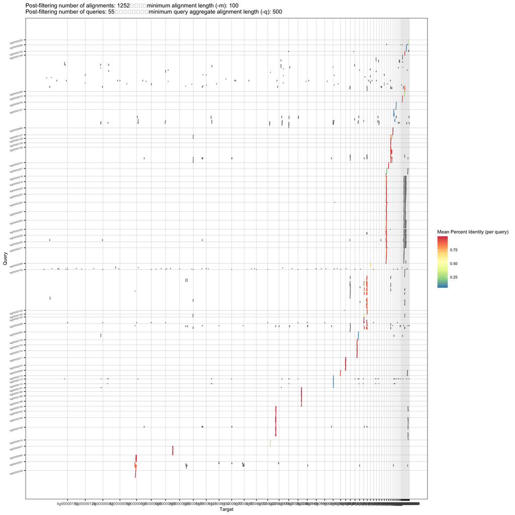

```bash
SAVE AS .paf so you can plot using this website (https://bioinformaticsworkbook.org/dataWrangling/genome-dotplots.html#gsc.tab=0)

#contig vs bubble
/Users/jakebotkin/Desktop/dotPlotly/pafCoordsDotPlotly.R -i /Users/jakebotkin/Desktop/a2_contig_vs_bubble.paf -o /Users/jakebotkin/Desktop/a2_contig_vs_bubble.plot -m 100 -q 500 -s -t -l -p 12
```

We can remove bubbles from canu assemblies because they are represented in the contigs.

### remove replicated contigs

This is a custom perl script to remove canu bubble contigs, which are represented other places in the assembly.

```bash
#! /usr/bin/perl -w
# rm_bubble.pl
#this script will alter the header in a fasta file to only contain the first string of characters after the >
use strict;
use Getopt::Long();

my $usage = "\nUsage: $0 --in <input fasta file> --out <new fasta> --out2 <new fasta> --help <help on usage of script>\n\n";

my ($in, $out, $out2, $help);

Getopt::Long::GetOptions('in=s' => \$in,
                         'out=s' => \$out,
                         'out2=s' => \$out2,
                         'h|help' => \$help);

if (defined($help)) {
    die $usage;
}

# Open file
open (my $in_fh, '<', $in) or die "Can't open $in\n\n";
# Open output
open (my $out_fh, '>', $out) or die "Can't open $out\n\n";
open (my $out2_fh, '>', $out2) or die "Can't open $out2\n\n";

#declare variables
#id array
my @id;
#header list
my $new_id;
my $id;

#loop for the input file
my $count = 0;
while (my $line = <$in_fh>) {

    #remove newline character
    chomp $line;
    if ($count eq 1) {
        if ($line !~ /^>/) {
            print $out_fh "$line\n";
        }
    }
    if ($count eq 2) {
        if ($line !~ /^>/) {
            print $out2_fh "$line\n";
        }
    }

    #if > in header continue following commands in brackets{}
    if ($line =~ /^>/) {
        $count = 0;
        #split the >header line by spaces, and put them into an array @id
        my @id = split(' ', $line);

        #take the 6th item in the array 'suggestBubble=yes/no' (call with $id), and put it into a list $new_id
        my $new_id = $id[5];

        if ($new_id =~ /^suggestBubble=no/) {
            #new_id now contains the only header info we want in a scalar list
             #print list to terminal
             #print "$line\n";
             #add new id list to output file
             print $out_fh "$line\n";
             $count = 1;
         }
         #If there is no > in the header,
         if ($new_id =~ /^suggestBubble=yes/) {
             #print the text as it appears in the input file to the ouput file.
             print $out2_fh "$line\n";
             $count = 2;
        }
    }
}

close $in_fh;

#exit perl
exit;
```

## 10. Racon

[Racon Pipeline](https://denbi-nanopore-training-course.readthedocs.io/en/latest/polishing/medaka/racon.html) Racon is a polishing software.

### racon mapping

The first step of racon is to generate a .sam mapping file by mapping the long-reads to the assembly.

```bash
#!/bin/bash -l
#SBATCH -N 1
#SBATCH -n 40
#SBATCH --time=48:00:00
#SBATCH -o /scratch.global/botki009/e_o_files/racon_mapping2.o
#SBATCH -e /scratch.global/botki009/e_o_files/racon_mapping2.e
#SBATCH --job-name=racon_mapping.sh
#SBATCH --mem=30G

module load bwa

bwa mem -t 40 /home/hirschc3/botki009/a3_no_bub.contigs.fasta /home/hirschc3/botki009/filter_ont/filter_ont/all_4_runs_q8_l2000.fastq.gz > /scratch.global/botki009/racon_a3_mapping.sam
```

### racon.sh

Run racon to polish assembly.

```bash
#!/bin/bash
#SBATCH -N 1
#SBATCH -n 14
#SBATCH --time=24:00:00
#SBATCH -o /scratch.global/botki009/e_o_files/racon_A3.o
#SBATCH -e /scratch.global/botki009/e_o_files/racon_A3.e
#SBATCH --job-name=racon_A3.sh
#SBATCH --mem=50G


/home/hirschc3/botki009/software/racon/build/bin/racon -m 8 -x -6 -g -8 -w 500 -t 14 /home/hirschc3/botki009/filter_ont/f
ilter_ont/all_4_runs_q8_l2000.fastq.gz /scratch.global/botki009/racon_a3_mapping.sam /home/hirschc3/botki009/a3_no_bub.co
ntigs.fasta > /home/hirschc3/botki009/a3_no_bub_r1.contigs.fasta
```

## 11. Medaka

Doing Medaka consensus on the contigs that have been corrected by racon once. Medaka is a polishing software that is similar to Racon. Medaka was used in a Anaconda environment (installed by MSI help desk) using a bioconda implementation of medaka at https://anaconda.org/bioconda/medaka.

### medaka align

Step 1 of medaka. Run bwa index in between each step.

```bash
#!/bin/bash
#SBATCH -N 1
#SBATCH -n 4
#SBATCH --time=24:00:00
#SBATCH -o /scratch.global/botki009/e_o_files/medaka_align3.6.o
#SBATCH -e /scratch.global/botki009/e_o_files/medaka_align3.6.e
#SBATCH --job-name=medaka_align2.sh
#SBATCH --mem=50G

#sbatch medaka_align2.sh

module load bcftools/1.6
module load htslib/1.6
module load minimap2/2.10
module load samtools/1.9
module load python/3.6.3

source activate medaka-env-3.6

mini_align -i /home/hirschc3/botki009/filter_ont/filter_ont/all_4_runs_q8_l2000.fastq -r /home/hirschc3/botki009/ac_genome_assembly/A2/a3_contigs_no_bub_r1.fasta -m r10_min_high_g303 -p calls_to_draft.bam -t 4

source deactivate medaka-env-3.6
```

### medaka consensus

Step 2 of medaka.

```bash
#!/bin/bash
#SBATCH -N 1
#SBATCH -n 40
#SBATCH --time=48:00:00
#SBATCH -o /scratch.global/botki009/e_o_files/medaka_consensus_12521.o
#SBATCH -e /scratch.global/botki009/e_o_files/medaka_consensus12521.e
#SBATCH --job-name=medaka_consensus2.sh
#SBATCH --mem=40G

#sbatch medaka_consensus2.sh

module load python/3.6.3

source activate medaka-env-3.6

medaka consensus ~/reads.bam ~/consensus_probs.hdf --model r10_min_high_g303 --threads 8 --chunk_len 500

conda deactivate
```

### medaka stitch

Step 3 of medaka.

```bash
#!/bin/bash
#SBATCH -N 1
#SBATCH -n 8
#SBATCH --time=8:00:00
#SBATCH -o /scratch.global/botki009/e_o_files/medaka_stitch_125.o
#SBATCH -e /scratch.global/botki009/e_o_files/medaka_stitch_125.e
#SBATCH --job-name=medaka_stitch.sh
#SBATCH --mem=20G

module load python/3.6.3

source activate medaka-env-3.6

medaka stitch --threads 8 /home/hirschc3/botki009/consensus_probs.hdf /home/hirschc3/botki009/ac_genome_assembly/A2/a2_contigs_no_bub_r1.fasta a2_contigs_no_bub_r1_m1.fasta

conda deactivate
```

## 12. Pilon

Pilon requires Illumina reads, which you map to the assembly first, then run Pilon on the .bam mapping files. Run Pilon twice on contigs.

### list file

This is a list file for trimmomatic.

```bash
/home/hirschc3/botki009/illumina_genome_data/sample.txt
103-1_B_S1_L001_R1_001
103-1_B_S1_L001_R2_001

adapter file:
/home/hirschc3/botki009/adapter_file_fixed.txt

trimmomatic dir:
/scratch.global/botki009/trimmomatic
```

### trimmomatic

Run trimmomatic on illumina reads to filter out bad reads.

```bash
#!/bin/bash
#SBATCH -N 1
#SBATCH -n 4
#SBATCH --time=12:00:00
#SBATCH -o /scratch.global/botki009/e_o_files/trim_o_file.o
#SBATCH -e /scratch.global/botki009/e_o_files/trim_e_file.e
#SBATCH --job-name=trimmomatic.sh
#SBATCH --mem=20G

#sbatch trimmomatic.sh

module load trimmomatic/0.33

cd /scratch.global/botki009/trimmomatic

java -jar $TRIMMOMATIC/trimmomatic.jar PE -phred33 -threads 4 -trimlog /scratch.global/botki009/trimmomatic/trimlog.txt /home/hirschc3/botki009/illumina_genome_data/forward_reads/103-1_B_S1_L001_R1_001.fastq.gz /home/hirschc3/botki009/illumina_genome_data/reverse_reads/103-1_B_S1_L001_R2_001.fastq.gz /scratch.global/botki009/trimmomatic/forward_paried.fastq.gz /scratch.global/botki009/trimmomatic/forward_unparied.fastq.gz /scratch.global/botki009/trimmomatic/reverse_paried.fastq.gz /scratch.global/botki009/trimmomatic/reverse_unparied.fastq.gz LEADING:10 TRAILING:10 SLIDINGWINDOW:4:15 ILLUMINACLIP:/home/hirschc3/botki009/adapter_file_fixed.txt:2:30:10:2:keepBothReads MINLEN:100
```

### fastqc

Run fastqc for trimmed illumina reads to QC reads.

```bash
#!/bin/bash
#SBATCH -N 1
#SBATCH -n 2
#SBATCH --time=6:00:00
#SBATCH -o /scratch.global/botki009/e_o_filesfastqc.o
#SBATCH -e /scratch.global/botki009/e_o_files/fastqc.e
#SBATCH --job-name=fastqc.sh
#SBATCH --mem=8G

module load fastqc/0.11.8

fastqc -o /scratch.global/botki009/fastqc --noextract -f fastq /scratch.global/botki009/trimmomatic/forward_paried.fastq.gz
```

### index contigs

```bash
bwa index contigs.fasta
```

### mapping paired

Generate .sam mapping file from paired illumina reads for pilon input.

```bash
#!/bin/bash
#SBATCH -N 1
#SBATCH -n 14
#SBATCH --time=12:00:00
#SBATCH -o /scratch.global/botki009/e_o_files/pilon_paired_map.o
#SBATCH -e /scratch.global/botki009/e_o_files/pilon_paired_map.e
#SBATCH --job-name=pilon_paired_map.sh
#SBATCH --mem=20G

#sbatch /scratch.global/botki009/pilon_paired_map.sh

module load bwa

bwa mem -t 14 contigs.fasta /scratch.global/botki009/trimmomatic/forward_paried.fastq.gz  /scratch.global/botki009/trimmomatic/reverse_paried.fastq.gz  > /scratch.global/botki009/pilon/pilon_paired_map.sam
```

### mapping unpaired

Generate .sam mapping file from unpaired illumina reads for pilon input.

```bash
#!/bin/bash
#SBATCH -N 1
#SBATCH -n 14
#SBATCH --time=12:00:00
#SBATCH -o /scratch.global/botki009/e_o_files/pilon_unpaired_map.o
#SBATCH -e /scratch.global/botki009/e_o_files/pilon_unpaired_map.e
#SBATCH --job-name=pilon_unpaired_map.sh
#SBATCH --mem=20G

#sbatch /scratch.global/botki009/pilon_unpaired_map.sh

module load bwa

bwa mem -t 14 contigs.fasta /scratch.global/botki009/trimmomatic/forward_unparied.fastq.gz /scratch.global/botki009/trimmomatic/reverse_unparied.fastq.gz > /scratch.global/botki009/pilon/pilon_unpaired_map.sam
```

### sort and index mapping files

```bash
### sort .sam and convert to .bam
module load samtools/1.9
samtools sort pilon_paired_map.sam > sort_paired.bam

### Index .bam files
module load samtools/1.9
samtools index /path/sort_paired.bam
```

### pilon

Run pilon using .bam mapping files as inputs.

```bash
#!/bin/bash -l
#SBATCH -N 1
#SBATCH -n 16
#SBATCH --time=48:00:00
#SBATCH -o /scratch.global/botki009/e_o_files/pilon.o
#SBATCH -e /scratch.global/botki009/e_o_files/pilon.e
#SBATCH --job-name=pilon.sh
#SBATCH --mem=100G

cd /panfs/roc/msisoft/pilon/1.22
module load /panfs/roc/soft/modulefiles.legacy/modulefiles.common/java/jdk1.8.0_45
export PATH="/panfs/roc/msisoft/pilon/1.22/bin:$PATH"
java -jar /panfs/roc/msisoft/pilon/1.22/bin/pilon-1.22.jar --genome /scratch.global/botki009/pilon/a3_contigs_no_bub_r1_m1.fasta --frags /scratch.global/botki009/pilon/sort_paired.bam --unpaired /scratch.global/botki009/pilon/sort_unpaired_f.bam --unpaired /scratch.global/botki009/pilon/sort_unpaired_r.bam --output pilon_a3 --outdir /scratch.global/botki009/pilon --changes
```

### Repeat Pilon error correction

index contigs that have been corrected by pilon once.

```bash
bwa index pilon_contigs.fasta
```

### mapping paired

Generate .sam mapping file from paired illumina reads for pilon #2 input.

```bash
#!/bin/bash
#SBATCH -N 1
#SBATCH -n 14
#SBATCH --time=12:00:00
#SBATCH -o /scratch.global/botki009/e_o_files/pilon2_paired_map.o
#SBATCH -e /scratch.global/botki009/e_o_files/pilon2_paired_map.e
#SBATCH --job-name=pilon_paired_map.sh
#SBATCH --mem=20G

#sbatch /scratch.global/botki009/pilon_paired_map.sh

module load bwa

bwa mem -t 14 /scratch.global/botki009/pilon/pilon1_a3.fasta /scratch.global/botki009/trimmomatic/forwar
d_paried.fastq.gz  /scratch.global/botki009/trimmomatic/reverse_paried.fastq.gz  > /scratch.global/botki
009/pilon/pilon2/pilon2_paired_map.sam
```

### mapping unpaired

Generate .sam mapping file from unpaired illumina reads for pilon #2 input.

```bash
#!/bin/bash
#SBATCH -N 1
#SBATCH -n 14
#SBATCH --time=12:00:00
#SBATCH -o /scratch.global/botki009/e_o_files/pilon2_unpaired_map.o
#SBATCH -e /scratch.global/botki009/e_o_files/pilon2_unpaired_map.e
#SBATCH --job-name=pilon_unpaired_map.sh
#SBATCH --mem=20G

#sbatch /scratch.global/botki009/pilon_unpaired_map.sh

module load bwa

bwa mem -t 14 /scratch.global/botki009/pilon/pilon1_a3.fasta /scratch.global/bot
ki009/trimmomatic/forward_unparied.fastq.gz  > /scratch.global/botki009/pilon/pi
lon2/pilon2_unpaired_f_map.sam
```

### sort and index

Sort and index mapping files for running pilon a second time.

```bash
### sort .sam and convert to .bam
module load samtools/1.9
samtools sort pilon2_paired_map.sam > sort_paired2.bam

### Index .bam files
module load samtools/1.9
samtools index /path/sort_paired2.bam
```

### pilon

Run pilon a second time using .bam mapping files as inputs.

```bash
#!/bin/bash -l
#SBATCH -N 1
#SBATCH -n 16
#SBATCH --time=48:00:00
#SBATCH -o /scratch.global/botki009/e_o_files/pilon2.o
#SBATCH -e /scratch.global/botki009/e_o_files/pilon2.e
#SBATCH --job-name=pilon.sh
#SBATCH --mem=100G

cd /panfs/roc/msisoft/pilon/1.22
module load /panfs/roc/soft/modulefiles.legacy/modulefiles.common/java/jdk1.8.0_45
export PATH="/panfs/roc/msisoft/pilon/1.22/bin:$PATH"
java -jar /panfs/roc/msisoft/pilon/1.22/bin/pilon-1.22.jar --genome /scratch.global/botki009/pilon/pilon
1_a3.fasta --frags /scratch.global/botki009/pilon/pilon2/sort_paired.bam --unpaired /scratch.global/botk
i009/pilon/pilon2/sort_unpaired_f.bam --unpaired /scratch.global/botki009/pilon/pilon2/sort_unpaired_r.b
am --output pilon2_a3 --outdir /scratch.global/botki009/pilon/pilon2/ --changes
```

## 13. QC assembly

### map Illumina reads to assembly (optional)

Paired illumina reads from 6 A.cochlioides isolates were filtered with trimmomatic, and mapped to the assembly as a quality check measure. Illumina reads were mapped at ANY quality with multi-mapping.

```bash
#!/bin/bash -l
#SBATCH -N 1
#SBATCH -n 16
#SBATCH --time=24:00:00
#SBATCH -o /scratch.global/botki009/e_o_files/bwa.o
#SBATCH -e /scratch.global/botki009/e_o_files/bwa.e
#SBATCH --job-name=bwa.sh
#SBATCH --mem=20G
#SBATCH --array=1-6

module load bwa

#location of LIST file
cd /home/hirschc3/botki009/

LINE=$(sed -n "$SLURM_ARRAY_TASK_ID"p ~/trim_samples.txt)

bwa mem -t 16 /scratch.global/botki009/pilon/pilon2/pilon2_a3.fasta ~/trimmomatic/${LINE}_forward_paried.fastq.gz ~/trimmomatic/${LINE}_reverse_paried.fastq.gz > /home/hirschc3/botki009/6_iso_alignment/${LINE}_paired.sam
```

### sam to bam

Convert .sam to .bam

```bash
#!/bin/bash -l
#SBATCH -N 1
#SBATCH -n 16
#SBATCH --time=6:00:00
#SBATCH -o /scratch.global/botki009/e_o_files/s_b.o
#SBATCH -e /scratch.global/botki009/e_o_files/s_b.e
#SBATCH --job-name=s_b.sh
#SBATCH --mem=30G
#SBATCH --array=1-6

module samtools/1.9

#location of LIST file
cd /home/hirschc3/botki009/

LINE=$(sed -n "$SLURM_ARRAY_TASK_ID"p ~/trim_samples.txt)

samtools view -bS  /home/hirschc3/botki009/6_iso_alignment/${LINE}_paired.sam >
 /home/hirschc3/botki009/6_iso_alignment/${LINE}_paired.bam
```

### flagstat

Run flagstat to get read mapping stats showing how many illumina reads mapped to the assembly.

```bash
submit array job: sbatch --array [1-6] ~/s_b.sh

#!/bin/bash -l
#SBATCH -N 1
#SBATCH -n 4
#SBATCH --time=12:00:00
#SBATCH -o /scratch.global/botki009/e_o_files/flagstat.sh.o
#SBATCH -e /scratch.global/botki009/e_o_files/flagstat.sh.e
#SBATCH --job-name=flagstat.sh
#SBATCH --mem=10G
#SBATCH --array=1-6

#location of LIST file
cd /home/hirschc3/botki009/

LINE=$(sed -n "$SLURM_ARRAY_TASK_ID"p ~/trim_samples.txt)

module load samtools/1.9

samtools flagstat /home/hirschc3/botki009/6_iso_alignment/${LINE}_paired.bam
```

### mapping stats output

Results: 6 isolate AVG = 99.91333 % mapped. Isoalte 103-1 mapping the best (99.95%).

```bash
Isolate 103-1:
23428280 + 0 in total (QC-passed reads + QC-failed reads)
0 + 0 secondary
8028 + 0 supplementary
0 + 0 duplicates
23417313 + 0 mapped (99.95% : N/A)
23420252 + 0 paired in sequencing
11710126 + 0 read1
11710126 + 0 read2
23373950 + 0 properly paired (99.80% : N/A)
23399788 + 0 with itself and mate mapped
9497 + 0 singletons (0.04% : N/A)
13690 + 0 with mate mapped to a different chr
4670 + 0 with mate mapped to a different chr (mapQ>=5)

Isolate M-1:
52233165 + 0 in total (QC-passed reads + QC-failed reads)
0 + 0 secondary
29201 + 0 supplementary
0 + 0 duplicates
52203289 + 0 mapped (99.94% : N/A)
52203964 + 0 paired in sequencing
26101982 + 0 read1
26101982 + 0 read2
52056252 + 0 properly paired (99.72% : N/A)
52166868 + 0 with itself and mate mapped
7220 + 0 singletons (0.01% : N/A)
75898 + 0 with mate mapped to a different chr
19349 + 0 with mate mapped to a different chr (mapQ>=5)

Isolate 13-35:
60415457 + 0 in total (QC-passed reads + QC-failed reads)
0 + 0 secondary
11975 + 0 supplementary
0 + 0 duplicates
60371574 + 0 mapped (99.93% : N/A)
60403482 + 0 paired in sequencing
30201741 + 0 read1
30201741 + 0 read2
60298974 + 0 properly paired (99.83% : N/A)
60358160 + 0 with itself and mate mapped
1439 + 0 singletons (0.00% : N/A)
37738 + 0 with mate mapped to a different chr
15531 + 0 with mate mapped to a different chr (mapQ>=5)

Isolate 64ss:
55957315 + 0 in total (QC-passed reads + QC-failed reads)
0 + 0 secondary
26393 + 0 supplementary
0 + 0 duplicates
55904144 + 0 mapped (99.90% : N/A)
55930922 + 0 paired in sequencing
27965461 + 0 read1
27965461 + 0 read2
55773956 + 0 properly paired (99.72% : N/A)
55873862 + 0 with itself and mate mapped
3889 + 0 singletons (0.01% : N/A)
64312 + 0 with mate mapped to a different chr
14738 + 0 with mate mapped to a different chr (mapQ>=5)

Isolate 61ss:
59684499 + 0 in total (QC-passed reads + QC-failed reads)
0 + 0 secondary
26609 + 0 supplementary
0 + 0 duplicates
59621853 + 0 mapped (99.90% : N/A)
59657890 + 0 paired in sequencing
29828945 + 0 read1
29828945 + 0 read2
59501588 + 0 properly paired (99.74% : N/A)
59590024 + 0 with itself and mate mapped
5220 + 0 singletons (0.01% : N/A)
52888 + 0 with mate mapped to a different chr
16373 + 0 with mate mapped to a different chr (mapQ>=5)

Isolate C10:
63420017 + 0 in total (QC-passed reads + QC-failed reads)
0 + 0 secondary
16007 + 0 supplementary
0 + 0 duplicates
63333261 + 0 mapped (99.86% : N/A)
63404010 + 0 paired in sequencing
31702005 + 0 read1
31702005 + 0 read2
63253062 + 0 properly paired (99.76% : N/A)
63315800 + 0 with itself and mate mapped
1454 + 0 singletons (0.00% : N/A)
35336 + 0 with mate mapped to a different chr
7743 + 0 with mate mapped to a different chr (mapQ>=5)
```

### BUSCO

Evaluate BUSCO’s present before and after pilon error correction. ### busco.sh

```bash
#!/bin/bash -l
#SBATCH -N 1
#SBATCH -n 16
#SBATCH --time=1:00:00
#SBATCH -o /scratch.global/botki009/e_o_files/busco.o
#SBATCH -e /scratch.global/botki009/e_o_files/busco.e
#SBATCH --job-name=busco.sh
#SBATCH --mem=12G

#sbatch busco.sh

module load python
module load ncbi_blast+/2.7.1.CentOS7
module load hmmer/3.1b2
module load augustus/3.2.3.CentOS7
module load busco/2.0
module load boost/1.61.0-python3.5.2

# export paths
export BUSCO_CONFIG_FILE="/home/hirschc3/botki009/software/busco/config/myconfig
.ini"
export AUGUSTUS_CONFIG_PATH=/home/hirschc3/botki009/software/augustus_config/
export PATH="/panfs/roc/msisoft/augustus/3.2.3.CentOS7/scripts:$PATH"
export PATH="/panfs/roc/msisoft/augustus/3.2.3.CentOS7/bin:$PATH"

cd /scratch.global/botki009/busco
busco -i   /scratch.global/botki009/pilon/pilon2/pilon2_a3.fasta  -o busco_a3_r1
_m1_p2 -l /home/hirschc3/botki009/software/busco/datasets/alveolata_stramenophil
es_ensembl -m genome -c 16 -sp aspergillus_nidulans -e 0.1
```

### busco results

The busco score improved from 91% to 93.2% with pilon.

```bash
# To reproduce this run: python /panfs/roc/msisoft/busco/2.0/bin/busco -i /scratch.global/botki009/pilon/pilon_a3.fasta -o busco_a3_pilon -l /home/hirschc3/botki009/software/busco/datasets/alveolata_stram
enophiles_ensembl/ -m genome -c 16 -sp aspergillus_nidulans -e 0.1
#
# Summarized benchmarking in BUSCO notation for file /scratch.global/botki009/pilon/pilon_a3.fasta
# BUSCO was run in mode: genome

    C:93.2%[S:93.2%,D:0.0%],F:0.4%,M:6.4%,n:234

    218 Complete BUSCOs (C)
    218 Complete and single-copy BUSCOs (S)
    0   Complete and duplicated BUSCOs (D)
    1   Fragmented BUSCOs (F)
    15  Missing BUSCOs (M)
    234 Total BUSCO groups searched
```

### quast

Compare assemblies easily by stats with this GUI.

```bash
#Using GUI at
http://cab.cc.spbu.ru/quast/
```

## 14. Annotate repeats

De novo annotate and identify repeats for soft masking. [Repeat Masking](http://www.repeatmasker.org/RepeatModeler/) Did not set up software paths during configuration for masking LTRs (should have done this). ### pre-steps (repeat modeler)

```bash
### run in one directory
mkdir repeatmodeler
cd repeatmodeler
put contigs.fa file here
## Changed name of contigs.fa to database name.fa
mv contigs.fa makeblast_db.fa
```

### makeblastdb.sh

Step 1 of Repeat Modeler.

```bash
#!/bin/bash
#SBATCH -N 1
#SBATCH -n 4
#SBATCH --time=12:00:00
#SBATCH -o /scratch.global/botki009/e_o_files/makeblastdb.o
#SBATCH -e /scratch.global/botki009/e_o_files/makeblastdb.e
#SBATCH --job-name=makeblastdb.sh
#SBATCH --mem=40G

#sbatch makeblastdb.sh

module load ncbi_blast+/2.8.1

makeblastdb -in /home/hirschc3/botki009/ac_genome_assembly/A2/polished_r1_m1_assembly_A2.fa -out /scratch.global/botki009/repeatmodeler/makeblast_db -parse_seqids -dbtype nucl
```

### build database

Step 2 of Repeat Modeler.

```bash
#!/bin/bash
#SBATCH -N 1
#SBATCH -n 14
#SBATCH --time=96:00:00
#SBATCH -o /scratch.global/botki009/e_o_files/repeatmodeler_db.o
#SBATCH -e /scratch.global/botki009/e_o_files/repeatmodeler_db.e
#SBATCH --job-name=repeatmodeler_new_db.sh
#SBATCH --mem=20G

export PATH="/panfs/roc/msisoft/repeatmodeler/1.0.11:$PATH"

module load rmblast/2.2.28
module load trf/407b_64
module load repeatmasker/4.0.5
module load perl
module load repeatscout/1.0.5
module load recon/1.08
module load repeatmodeler/1.0.11

cd /scratch.global/botki009/repeatmodeler/

/panfs/roc/msisoft/repeatmodeler/1.0.11/BuildDatabase -name makeblast_db -engine ncbi /scratch.global/botki009/repeatmodeler/makeblast_db.fa
```

### Repeat Modeler

Run Repeat Modeler.

```bash
#!/bin/bash
#SBATCH -N 1
#SBATCH -n 14
#SBATCH --time=96:00:00
#SBATCH -o /scratch.global/botki009/e_o_files/repeatmodeler_new.o
#SBATCH -e /scratch.global/botki009/e_o_files/repeatmodeler_new.e
#SBATCH --job-name=repeatmodeler_new.sh
#SBATCH --mem=20G

export PATH="/panfs/roc/msisoft/repeatmodeler/1.0.11:$PATH"

module load rmblast/2.2.28
module load trf/407b_64
module load repeatmasker/4.0.5
module load perl
module load repeatscout/1.0.5
module load recon/1.08
module load repeatmodeler/1.0.11

cd /scratch.global/botki009/repeatmodeler/

/panfs/roc/msisoft/repeatmodeler/1.0.11/RepeatModeler -database makeblast_db
```

### pre-steps (repeat masker)

```bash
# make new dir "repeatmasker"
mkdir repeatmasker
cd repeatmasker
# softlink classify file in dir
ln -s ~/repeatmodeler/RM_2578281.ThuJan281434542021/consensi.fa.classified
```

### Repeat Masker

Run Repeat Masker to make a soft masked contigs.fasta file, and a table with repeat types and counts.

```bash
#!/bin/bash
#SBATCH -N 1
#SBATCH -n 16
#SBATCH --time=12:00:00
#SBATCH -o /scratch.global/botki009/e_o_files/repeatmasker.o
#SBATCH -e /scratch.global/botki009/e_o_files/repeatmasker.e
#SBATCH --job-name=repeatmasker.sh
#SBATCH --mem=20G

#sbatch repeatmasker.sh

module load trf/407b_64
module load recon/1.08
module load rmblast/2.2.28
module load repeatmasker/4.0.5

export PATH="/panfs/roc/msisoft/repeatmasker/4.0.5:$PATH"

cd /scratch.global/botki009/repeatmasker

/panfs/roc/msisoft/repeatmasker/4.0.5/RepeatMasker -pa 16 -xsmall -gff -lib consensi.fa.cl
assified ~/repeatmodeler/makeblast_db.fa
```

### Repeat Modeler/Masker output

Repeat stats for assembly.

```bash
==================================================
file name: makeblast_db.fa
sequences:            97
total length:   76355735 bp  (76355735 bp excl N/X-runs)
GC level:         47.39 %
bases masked:   24538171 bp ( 32.14 %)
==================================================
               number of      length   percentage
               elements*    occupied  of sequence
--------------------------------------------------
SINEs:             1273      1250054 bp    1.64 %
      ALUs            0            0 bp    0.00 %
      MIRs            0            0 bp    0.00 %

LINEs:             2289      6295630 bp    8.25 %
      LINE1         661      1743521 bp    2.28 %
      LINE2         103        43921 bp    0.06 %
      L3/CR1          0            0 bp    0.00 %

LTR elements:      1758      2693519 bp    3.53 %
      ERVL            0            0 bp    0.00 %
      ERVL-MaLRs      0            0 bp    0.00 %
      ERV_classI      0            0 bp    0.00 %
      ERV_classII     0            0 bp    0.00 %

DNA elements:      4575      3166687 bp    4.15 %
     hAT-Charlie      0            0 bp    0.00 %
     TcMar-Tigger   129        81678 bp    0.11 %

Unclassified:     16826     10624337 bp   13.91 %

Total interspersed repeats: 24030227 bp   31.47 %


Small RNA:          253       274845 bp    0.36 %

Satellites:           0            0 bp    0.00 %
Simple repeats:    3948       215816 bp    0.28 %
Low complexity:     401        18974 bp    0.02 %
==================================================

* most repeats fragmented by insertions or deletions
  have been counted as one element


The query species was assumed to be homo
RepeatMasker version open-4.0.5 , default mode

run with rmblastn version 2.2.27+
The query was compared to classified sequences in "consensi.fa.classified"
RepBase Update 20140131, RM database version 20140131
```

### LTR finder

Run LTR finder to identify LTR retrotransposons.

```bash
#!/bin/bash -l
#SBATCH -N 1
#SBATCH -n 4
#SBATCH --time=24:00:00
#SBATCH -o /scratch.global/botki009/e_o_files/ltr_find.o
#SBATCH -e /scratch.global/botki009/e_o_files/ltr_find.e
#SBATCH --job-name=ltr_find.sh
#SBATCH --mem=5G


~/software/ltr/LTR_retriever/LTR_Finder/source/ltr_finder ~/ac_genome_assembly/A3/pilon2_a3_sorted.fasta > ~/ltr_finder_out.txt
```

### LTR retiever

Annotate LTR retrotransposons and calculate LAI (LTR index for assessmnet of repeat completeness) using output of LTR finder.

```bash
#!/bin/bash -l
#SBATCH -N 1
#SBATCH -n 40
#SBATCH --time=96:00:00
#SBATCH -o /scratch.global/botki009/e_o_files/ltr2.o
#SBATCH -e /scratch.global/botki009/e_o_files/ltr2.e
#SBATCH --job-name=ltr.sh
#SBATCH --mem=50G

conda activate LTR_retriever

/home/hirschc3/botki009/software/ltr/LTR_retriever/LTR_retriever -genome ~/ac_genome_assembly/A3/pilon2_a3_sorted.fasta -infinde
r ~/ltr_finder_out.txt

conda deactivate
```

## 15. Annotate genes

[funannotate 1.8.1](https://funannotate.readthedocs.io/en/latest/)

### Map RNA to AC assembly to get RNA for annotation

Our RNA-seq data had plant and pathogen RNA mixed, so we needed to extract RNA only belonging to our pathogen. Map RNA to assembly and remove mapped reads to use for training funannotate.

```bash
MAPPING WITH STAR
#!/bin/bash -l
#SBATCH -N 1
#SBATCH -n 16
#SBATCH --time=2:00:00
#SBATCH -o /scratch.global/botki009/e_o_files/star.o
#SBATCH -e /scratch.global/botki009/e_o_files/star.e
#SBATCH --job-name=star.sh
#SBATCH --mem=10G

module load star/2.5.3a

STAR --runThreadN 16 --limitGenomeGenerateRAM 50000000000 --runMode genomeGenerate --genomeDir /scratch.global/botki009/genome --genomeFastaFiles /scratch.global/botki009/genome/A_cochlio
ides_genome.fasta

#!/bin/bash -l
#SBATCH -N 1
#SBATCH -n 16
#SBATCH --time=48:00:00
#SBATCH -o /scratch.global/botki009/e_o_files/star_map.o
#SBATCH -e /scratch.global/botki009/e_o_files/star_map.e
#SBATCH --job-name=star_map.sh
#SBATCH --mem=100G
#SBATCH --array=1-6

LINE=$(sed -n "$SLURM_ARRAY_TASK_ID"p /scratch.global/botki009/map_to_aphan/list.txt)

module load star/2.5.3a

export PATH="/panfs/roc/msisoft/star/2.5.3a/bin/Linux_x86_64:$PATH"

STAR --runThreadN 16 --twopassMode Basic --outFileNamePrefix /scratch.global/botki009/genome/${LINE}_mapped --genomeDir /scratch.global/botki009/genome --readFilesCommand gunzip -c --read
FilesIn /home/hirschc3/botki009/rna_ac_reads/forward_reads/${LINE}_R1_001.fastq.gz /home/hirschc3/botki009/rna_ac_reads/reverse_reads/${LINE}_R2_001.fastq.gz

#!/bin/bash -l
#SBATCH -N 1
#SBATCH -n 16
#SBATCH --time=4:00:00
#SBATCH -o /scratch.global/botki009/e_o_files/sam_sort.o
#SBATCH -e /scratch.global/botki009/e_o_files/sam_sort.e
#SBATCH --job-name=sam_sort.sh
#SBATCH --mem=80G
#SBATCH --array=1-6

module load samtools/1.9

LINE=$(sed -n "$SLURM_ARRAY_TASK_ID"p /home/hirschc3/botki009/list.txt)

samtools sort -n -T ${LINE}sorted /scratch.global/botki009/genome/finished_sam/${LINE}_mappedAligned.out.sam -o /scratch.
```

#convert .sam files of mapped RNA reads to fastq files Get the RNA reads that mapped to the assembly (some file names may be off).

```bash
SAM to BAM
#!/bin/bash -l
#SBATCH -N 1
#SBATCH -n 16
#SBATCH --time=4:00:00
#SBATCH -o /scratch.global/botki009/e_o_files/sam_bam_flag.o
#SBATCH -e /scratch.global/botki009/e_o_files/sam_bam_flag.e
#SBATCH --job-name=sam_bam.sh
#SBATCH --mem=70G
#SBATCH --array=1-6

module load minimap2/2.10
module load samtools/1.9

LINE=$(sed -n "$SLURM_ARRAY_TASK_ID"p /home/hirschc3/botki009/rna_ac_reads/list.txt)

samtools view -bS /home/hirschc3/botki009/map_rna_sugar_beet/map_to_aphan/bam/${LINE}.sam > /home/hirschc3/botki009/map_rna_sugar_beet/map_to_aphan/bam/${LINE}.bam

###########################################################
FILTER MAPPED BAM
#!/bin/bash -l
#SBATCH -N 1
#SBATCH -n 16
#SBATCH --time=4:00:00
#SBATCH -o /scratch.global/botki009/e_o_files/sam_view.o
#SBATCH -e /scratch.global/botki009/e_o_files/sam_view.e
#SBATCH --job-name=sam_view.sh
#SBATCH --mem=80G
#SBATCH --array=1-6

module load samtools

LINE=$(sed -n "$SLURM_ARRAY_TASK_ID"p /scratch.global/botki009/map_to_aphan/list.txt)

samtools view -F 4 -q 0 -b -o /scratch.global/botki009/map_to_aphan/bam/${LINE}_mapped.bam /scratch.global/botki009/map_to_aphan/bam/${LINE}.bam

###########################################################
SAM TO FASTQ FOR PAIRED READS
#!/bin/bash -l
#SBATCH -N 1
#SBATCH -n 16
#SBATCH --time=4:00:00
#SBATCH -o /scratch.global/botki009/e_o_files/sam_fastq2.o
#SBATCH -e /scratch.global/botki009/e_o_files/sam_fastq2.e
#SBATCH --job-name=sam_fastq.sh
#SBATCH --mem=80G
#SBATCH --array=1-6

module load /panfs/roc/soft/modulefiles.legacy/modulefiles.common/java/jdk1.8.0_45
module load picard/2.9.0

LINE=$(sed -n "$SLURM_ARRAY_TASK_ID"p /scratch.global/botki009/map_to_aphan/list.txt)

export PATH="/panfs/roc/msisoft/picard/2.9.0:$PATH"
export CLASSPATH="/panfs/roc/msisoft/picard/2.9.0"
export LD_LIBRARY_PATH="/panfs/roc/msisoft/picard/2.9.0"

java -jar /panfs/roc/msisoft/picard/2.18.16/picard.jar SamToFastq INPUT=/scratch.global/botki009/map_to_aphan/bam/${LINE}_mapped.sam SECOND_END_FASTQ=/scratch.global/botki009/map_to_aphan/bam/fastq_mapped_rna/${LINE}_mapped_paired.fastq

###########################################################
SAM TO FASTQ FOR UNPAIRED READS
#!/bin/bash -l
#SBATCH -N 1
#SBATCH -n 16
#SBATCH --time=4:00:00
#SBATCH -o /scratch.global/botki009/e_o_files/sam_fastq2.o
#SBATCH -e /scratch.global/botki009/e_o_files/sam_fastq2.e
#SBATCH --job-name=sam_fastq.sh
#SBATCH --mem=80G
#SBATCH --array=1-6

module load /panfs/roc/soft/modulefiles.legacy/modulefiles.common/java/jdk1.8.0_45
module load picard/2.9.0

LINE=$(sed -n "$SLURM_ARRAY_TASK_ID"p /scratch.global/botki009/map_to_aphan/list.txt)

export PATH="/panfs/roc/msisoft/picard/2.9.0:$PATH"
export CLASSPATH="/panfs/roc/msisoft/picard/2.9.0"
export LD_LIBRARY_PATH="/panfs/roc/msisoft/picard/2.9.0"

java -jar /panfs/roc/msisoft/picard/2.18.16/picard.jar SamToFastq INPUT=/scratch.global/botki009/map_to_aphan/bam/${LINE}_mapped.sam UNPAIRED_FASTQ=/scratch.global/botki009/map_to_aphan/bam/fastq_mapped_rna/${LINE}_mapped_unpaired.fastq
```

### clean & sort contigs

Do this with funannotate software prior to running to remove replicated contigs and sort them.

```bash
1. Clean - remove contigs represented other places up to N50.

module load funannotate/1.8.1
funannotate clean -i a3_p2_contigs.soft_masked.fa -o a3_p2_contigs.soft_masked_clean_exhaustive.fa --exhaustive

2. Sort - sorts contigs large to small and rename headers with scaffold 1-n.

module load funannotate/1.8.1
funannotate sort -i a3_p2_contigs.soft_masked_clean_exhaustive.fa  -o ~/a3_p2_contigs.soft_masked_clean_exhaustive_sort.fa

3. Rename contigs.fasta.

 mv a3_p2_contigs.soft_masked_clean_exhaustive_sort.fa a3_contig_soft_mask_annotate.fa
```

### Install dataset

Add dataset for organism (alveolata_stramenophiles).

```bash
funannotate setup -b alveolata_stramenophiles -d /home/hirschc3/botki009/software/busco/datasets/alveolata_stramenophiles_ensembl
```

### Train funannotate

```bash
1. funannotate train

#!/bin/bash -l
#SBATCH -N 1
#SBATCH -n 40
#SBATCH --time=96:00:00
#SBATCH -o /scratch.global/botki009/e_o_files/funannotate_train.o
#SBATCH -e /scratch.global/botki009/e_o_files/funannotate_train.e
#SBATCH --job-name=funannotate_train.sh
#SBATCH --mem=200G

module load trinity/2.8.5
module load funannotate/1.8.1
module load pasa/2.3.3
module load evidencemodeler/1.1.1
module load signalp/4.1
module load eggnog-mapper/1.0.3
module load interproscan/5.23-62.0-openjdk
module load trinity/2.8.5
module load hisat2/2.1.0
module load samtools/1.9
module load fasta36/36.3.6d_serial
module load minimap2/2.10
module load pasa/2.3.3
module load python2/2.7.16_anaconda2019.10
module load perl/modules.centos7.5.26.1
module load gmap/2018-07-04
module load bamtools/20120608

#funannotate train ENV variables
export TRINITYHOME="/panfs/roc/msisoft/funannotate/1.8.1/opt/trinity-2.8.5"
export PASAHOME="/panfs/roc/msisoft/pasa/2.3.3"

#funannotate ENV variables
export AUGUSTUS_CONFIG_PATH="/panfs/roc/msisoft/funannotate/1.8.1/config"
export QUARRY_PATH="/panfs/roc/msisoft/funannotate/1.8.1/opt/codingquarry-2.0/QuarryFiles"
export FUNANNOTATE_DB="/home/hirschc3/botki009/software/busco/datasets/alveolata_stramenophiles_ensembl"
export GENEMARK_PATH="/panfs/roc/msisoft/genemark/4.61"
export TMPDIR="/scratch.global/botki009"
export MPLBACKEND="Agg"
export EVM_HOME="/panfs/roc/msisoft/evidencemodeler/1.1.1"
export BAMTOOLS_PATH="/panfs/roc/msisoft/bamtools/20120608/bin"
export LD_LIBRARY_PATH="/panfs/roc/msisoft/bamtools/20120608/lib"
export PATH="/panfs/roc/msisoft/funannotate/1.8.1:$PATH"
export PATH="/panfs/roc/msisoft/funannotate/1.8.1/bin:$PATH"
export PATH="/panfs/roc/msisoft/funannotate/1.8.1/python_deps/bin:$PATH"
export PATH="/panfs/roc/msisoft/evidencemodeler/1.1.1:$PATH"
export PATH="/panfs/roc/msisoft/bamtools/20120608/bin:$PATH"
export PATH="/panfs/roc/msisoft/gmap/2018-07-04/bin:$PATH"
export PATH="/panfs/roc/msisoft/signalp4/4.1:$PATH"
export PATH="/panfs/roc/msisoft/genemark/4.61:$PATH"

cd /scratch.global/botki009/genome/mapping_filter/

LINE=$(sed -n "$SLURM_ARRAY_TASK_ID"p /home/hirschc3/botki009/list.txt)

/panfs/roc/msisoft/funannotate/1.8.1/bin/funannotate train -i /home/hirschc3/botki009/annotate/a3_contig_soft_ma
sk_annotate.fa -o /home/hirschc3/botki009/annotate -l /scratch.global/botki009/genome/mapping_filter/R1_rna_mapp
ed_ac.fastq -r /scratch.global/botki009/genome/mapping_filter/R2_rna_mapped_ac.fastq --trinity /home/hirschc3/bo
tki009/ncbi_ac_data/trinity_ncbi/Trinity.fasta --jaccard_clip --no_trimmomatic --species "Aphanomyces cochlioide
s" --isolate 103-1 --cpus 20
```

### funannotate predict

```bash
2.funannotate predict

#!/bin/bash -l
#SBATCH -N 1
#SBATCH -n 14
#SBATCH --time=24:00:00
#SBATCH -o /scratch.global/botki009/e_o_files/funannotate3.o
#SBATCH -e /scratch.global/botki009/e_o_files/funannotate3.e
#SBATCH --job-name=funannotate.sh
#SBATCH --mem=100G

module load funannotate/1.8.1
module load pasa/2.3.3
module load evidencemodeler/1.1.1
module load signalp/4.1
module load eggnog-mapper/1.0.3
module load interproscan/5.23-62.0-openjdk
module load trinity/2.8.5
module load hisat2/2.1.0
module load samtools/1.9
module load fasta36/36.3.6d_serial
module load minimap2/2.10
module load pasa/2.3.3
module load python2/2.7.16_anaconda2019.10
module load gmap/2018-07-04
module load bamtools/20120608
module load genemark/4.61

export TRINITYHOME="/panfs/roc/msisoft/funannotate/1.8.1/opt/trinity-2.8.5"
export AUGUSTUS_CONFIG_PATH="/panfs/roc/msisoft/funannotate/1.8.1/config"
export QUARRY_PATH="/panfs/roc/msisoft/funannotate/1.8.1/opt/codingquarry-2.0/QuarryFiles"
export FUNANNOTATE_DB="/home/hirschc3/botki009/software/busco/datasets/alveolata_stramenophiles_ensembl"
export PASAHOME="/panfs/roc/msisoft/pasa/2.3.3"
export GENEMARK_PATH="/panfs/roc/msisoft/genemark/4.61"
export TMPDIR="/scratch.global/botki009"
export MPLBACKEND="Agg"
export EVM_HOME="/panfs/roc/msisoft/evidencemodeler/1.1.1"
export BAMTOOLS_PATH="/panfs/roc/msisoft/bamtools/20120608/bin"
export LD_LIBRARY_PATH="/panfs/roc/msisoft/bamtools/20120608/lib"
export PATH="/panfs/roc/msisoft/funannotate/1.8.1:$PATH"
export PATH="/panfs/roc/msisoft/funannotate/1.8.1/bin:$PATH"
export PATH="/panfs/roc/msisoft/funannotate/1.8.1/python_deps/bin:$PATH"
export PATH="/panfs/roc/msisoft/evidencemodeler/1.1.1:$PATH"
export PATH="/panfs/roc/msisoft/bamtools/20120608/bin:$PATH"
export PATH="/panfs/roc/msisoft/gmap/2018-07-04/bin:$PATH"
export PATH="/panfs/roc/msisoft/signalp4/4.1:$PATH"
export PATH="/panfs/roc/msisoft/genemark/4.61:$PATH"

/panfs/roc/msisoft/funannotate/1.8.1/bin/funannotate predict -i /home/hirschc3/botki009/annotate/a3_contig_soft_mask_annotate.fa -o /home/hirschc3/botki009/annotate -s "Aphanomyces cochlioides" --busco_db alveolata_stramenophiles --organism other --isolate 103-1  --name AC1031_ --protein_evidence /home/hirschc3/botki009/annotate/aphan_eutiches_evid/Aphanomyces_euteichesV3.pep.fa --pasa_gff /home/hirschc3/botki009/annotate/training/funannotate_train.pasa.gff3 --rna_bam /home/hirschc3/botki009/annotate/training/funannotate_train.coordSorted.bam --transcript_evidence /home/hirschc3/botki009/annotate/training/trinity.fasta /home/hirschc3/bo
tki009/ncbi_ac_data/trinity_ncbi/Trinity.fasta
```

### SBT file

Need a bioproject and biosample number in order to generate a SBT file from NCBI (not important).

```bash
#get file at:
https://submit.ncbi.nlm.nih.gov/genbank/template/submission/
```

### funannotate update

Update UTR data with PASA.

```bash
PRE-STEPS:
1.Open all dir permissions before running (chmod -R 777).
2. Move training directory to home.
3. Copy symbiolic link files (fun_update inputs) to home.
4. Delete symbiolic links from trainig dir, move copied files back into training (in home dir).
5. Run fun_update with trinity input in home/training and 1 thread.

#!/bin/bash -l
#SBATCH -N 1
#SBATCH -n 1
#SBATCH --time=150:00:00
#SBATCH -o /scratch.global/botki009/e_o_files/fun_update.o
#SBATCH -e /scratch.global/botki009/e_o_files/fun_update.e
#SBATCH --job-name=funann_update.sh
#SBATCH --mem=40G

module load funannotate/1.8.1
module load pasa/2.3.3
module load evidencemodeler/1.1.1
module load signalp/4.1
module load eggnog-mapper/1.0.3
module load interproscan/5.23-62.0-openjdk
module load trinity/2.8.5
module load hisat2/2.1.0
module load samtools/1.9
module load fasta36/36.3.6d_serial
module load minimap2/2.10
module load pasa/2.3.3
module load gmap/2018-07-04
module load bamtools/20120608
module load genemark/4.61
module load perl/5.26.1
module load perl/modules.centos7.5.26.1
module load bedtools/2.29.2
module load kallisto/0.46.2

export TRINITYHOME="/panfs/roc/msisoft/funannotate/1.8.1/opt/trinity-2.8.5"
export AUGUSTUS_CONFIG_PATH="/panfs/roc/msisoft/funannotate/1.8.1/config"
export QUARRY_PATH="/panfs/roc/msisoft/funannotate/1.8.1/opt/codingquarry-2.0/QuarryFiles"
export FUNANNOTATE_DB="/home/hirschc3/botki009/software/busco/datasets/alveolata_stramenophiles_ensembl"
export PASAHOME="/panfs/roc/msisoft/pasa/2.3.3"
export GENEMARK_PATH="/panfs/roc/msisoft/genemark/4.61"
export TMPDIR="/scratch.global/botki009"
export MPLBACKEND="Agg"
export EVM_HOME="/panfs/roc/msisoft/evidencemodeler/1.1.1"
export BAMTOOLS_PATH="/panfs/roc/msisoft/bamtools/20120608/bin"
export LD_LIBRARY_PATH="/panfs/roc/msisoft/bamtools/20120608/lib"
export PATH="/panfs/roc/msisoft/funannotate/1.8.1:$PATH"
export PATH="/panfs/roc/msisoft/funannotate/1.8.1/bin:$PATH"
export PATH="/panfs/roc/msisoft/funannotate/1.8.1/python_deps/bin:$PATH"
export PATH="/panfs/roc/msisoft/evidencemodeler/1.1.1:$PATH"
export PATH="/panfs/roc/msisoft/bamtools/20120608/bin:$PATH"
export PATH="/panfs/roc/msisoft/gmap/2018-07-04/bin:$PATH"
export PATH="/panfs/roc/msisoft/signalp4/4.1:$PATH"
export PATH="/panfs/roc/msisoft/genemark/4.61:$PATH"

cd /home/hirschc3/botki009/annotate/

/panfs/roc/msisoft/funannotate/1.8.1/bin/funannotate update -i /home/hirschc3/botki009/annotate/ --cpus 1 --species "Aphanomyces cochlioides" --no_trimmomatic --no_normalize_reads --trinity /home/hirschc3/botki009/training/funannotate_train.trinity-GG.fasta --left /home/hirschc3/botki009/rna_ac_reads/read_mapped_to_ac_genome/R1_rna_mapped_ac.fastq.gz --right /home/hirschc3/botki009/rna_ac_reads/read_mapped_to_ac_genome/R2_rna_mapped_ac.fastq.gz
```

### Interproscan

Docs- https://interproscan-docs.readthedocs.io/en/latest/HowToRun.html Annotate updated proteins.

```bash
#!/bin/bash -l
#SBATCH -N 1
#SBATCH -n 40
#SBATCH --time=96:00:00
#SBATCH -o /scratch.global/botki009/e_o_files/iprscan_41.o
#SBATCH -e /scratch.global/botki009/e_o_files/iprscan_41.e
#SBATCH --job-name=iprscan.sh
#SBATCH --mem=40G

module unload python/3.6.3
module unload python2/2.7.12_anaconda4.2
module unload python3/3.6.3_anaconda5.0.1

module load interproscan/5.23-62.0-openjdk
module load java/openjdk-8_202

#funannotate ipscan ENV variables
export JAVA_HOME="/panfs/roc/msisoft/java/openjdk-8_202"
export PATH="/panfs/roc/msisoft/java/openjdk-8_202/bin:$PATH"


/panfs/roc/msisoft/interproscan/5.23-62.0/interproscan.sh -appl CDD,COILS,Gene3D,HAMAP,MobiDBLite,PANTHER,Pfam,PIRSF,PRINTS,PROSITEPATTERNS,PROSITEPROFILES,SFLD,SMART,SUPERFAMILY,TIGRFA
M -i /home/hirschc3/botki009/annotate/update_results/Aphanomyces_cochlioides_103-1.proteins.fa -b /home/hirschc3/botki009/annotate/ipscan/Aphanomyces_cochlioides_ipscan -T ~/annotate/ip
scan -f XML -dp
```

### funannotate annotate

```bash
#!/bin/bash -l
#SBATCH -N 1
#SBATCH -n 14
#SBATCH --time=96:00:00
#SBATCH -o /scratch.global/botki009/e_o_files/funannotate_annotate.o
#SBATCH -e /scratch.global/botki009/e_o_files/funannotate_annotate.e
#SBATCH --job-name=funannotate_annotate.sh
#SBATCH --mem=30G

module load trinity/2.8.5
module load funannotate/1.8.1
module load pasa/2.3.3
module load evidencemodeler/1.1.1
module load signalp/4.1
module load eggnog-mapper/1.0.3
module load interproscan/5.23-62.0-openjdk
module load trinity/2.8.5
module load hisat2/2.1.0
module load samtools/1.9
module load fasta36/36.3.6d_serial
module load minimap2/2.10
module load pasa/2.3.3
module load gmap/2018-07-04
module load bamtools/20120608
module load /panfs/roc/soft/modulefiles.legacy/modulefiles.common/gcc/4.8.2
module load diamond/0.7.11

#funannotate train ENV variables
export TRINITYHOME="/panfs/roc/msisoft/funannotate/1.8.1/opt/trinity-2.8.5"
export PASAHOME="/panfs/roc/msisoft/pasa/2.3.3"

#funannotate ENV variables
export AUGUSTUS_CONFIG_PATH="/panfs/roc/msisoft/funannotate/1.8.1/config"
export QUARRY_PATH="/panfs/roc/msisoft/funannotate/1.8.1/opt/codingquarry-2.0/QuarryFiles"
export GENEMARK_PATH="/panfs/roc/msisoft/genemark/4.61"
export TMPDIR="/scratch.global/botki009"
export MPLBACKEND="Agg"
export EVM_HOME="/panfs/roc/msisoft/evidencemodeler/1.1.1"
export BAMTOOLS_PATH="/panfs/roc/msisoft/bamtools/20120608/bin"
export LD_LIBRARY_PATH="/panfs/roc/msisoft/bamtools/20120608/lib"
export PATH="/panfs/roc/msisoft/funannotate/1.8.1:$PATH"
export PATH="/panfs/roc/msisoft/funannotate/1.8.1/bin:$PATH"
export PATH="/panfs/roc/msisoft/funannotate/1.8.1/python_deps/bin:$PATH"
export PATH="/panfs/roc/msisoft/evidencemodeler/1.1.1:$PATH"
export PATH="/panfs/roc/msisoft/bamtools/20120608/bin:$PATH"
export PATH="/panfs/roc/msisoft/gmap/2018-07-04/bin:$PATH"
export PATH="/panfs/roc/msisoft/signalp4/4.1:$PATH"
export PATH="/panfs/roc/msisoft/genemark/4.61:$PATH"

cd /home/hirschc3/botki009/annotate

/panfs/roc/msisoft/funannotate/1.8.1/bin/funannotate annotate -i /home/hirschc3/botki009/annotate/update_results --cpus 7 -o /home/hirschc3/botki009/annotate/  --iprscan /home/hirschc3/botki009/annotate/ipscan/Aphanomyces_cochlioides_ipscan.xml --species "Aphanomyces cochlioides" --gff ~/annotate/update_results/Aphanomyces_cochlioides_103-1.gff3 --fasta ~/annotate/a3_
contig_soft_mask_annotate.fa --sbt /home/hirschc3/botki009/annotate/sbt.txt
```

### funannotate fix

Remove problem genes. Do this prior to NCBI submission.

```bash
#!/bin/bash -l
#SBATCH -N 1
#SBATCH -n 14
#SBATCH --time=12:00:00
#SBATCH -o /scratch.global/botki009/e_o_files/fun_fix.o
#SBATCH -e /scratch.global/botki009/e_o_files/fun_fix.e
#SBATCH --job-name=fun_fix.sh
#SBATCH --mem=10G

module load trinity/2.8.5
module load funannotate/1.8.1
module load pasa/2.3.3
module load evidencemodeler/1.1.1
module load signalp/4.1
module load eggnog-mapper/1.0.3
module load interproscan/5.23-62.0-openjdk
module load trinity/2.8.5
module load hisat2/2.1.0
module load samtools/1.9
module load fasta36/36.3.6d_serial
module load minimap2/2.10
module load pasa/2.3.3
module load perl/modules.centos7.5.26.1
module load gmap/2018-07-04
module load bamtools/20120608
module load java/openjdk-8_202
module load python2/2.7.12_anaconda4.2
module load /panfs/roc/soft/modulefiles.legacy/modulefiles.common/gcc/4.8.2
module load phobius/1.01

#funannotate ipscan ENV variables
export JAVA_HOME="/panfs/roc/msisoft/java/openjdk-8_202"
export PATH="/panfs/roc/msisoft/java/openjdk-8_202/bin:$PATH"

#funannotate train ENV variables
export TRINITYHOME="/panfs/roc/msisoft/funannotate/1.8.1/opt/trinity-2.8.5"
export PASAHOME="/panfs/roc/msisoft/pasa/2.3.3"

#funannotate ENV variables
export AUGUSTUS_CONFIG_PATH="/panfs/roc/msisoft/funannotate/1.8.1/config"
export QUARRY_PATH="/panfs/roc/msisoft/funannotate/1.8.1/opt/codingquarry-2.0/QuarryFiles"
export FUNANNOTATE_DB="/home/hirschc3/botki009/software/busco/datasets/alveolata_stramenophiles_ensembl"
export GENEMARK_PATH="/panfs/roc/msisoft/genemark/4.61"
export TMPDIR="/scratch.global/botki009"
export MPLBACKEND="Agg"
export EVM_HOME="/panfs/roc/msisoft/evidencemodeler/1.1.1"
export BAMTOOLS_PATH="/panfs/roc/msisoft/bamtools/20120608/bin"
export LD_LIBRARY_PATH="/panfs/roc/msisoft/bamtools/20120608/lib"
export PATH="/panfs/roc/msisoft/funannotate/1.8.1:$PATH"
export PATH="/panfs/roc/msisoft/funannotate/1.8.1/bin:$PATH"
export PATH="/panfs/roc/msisoft/funannotate/1.8.1/python_deps/bin:$PATH"
export PATH="/panfs/roc/msisoft/evidencemodeler/1.1.1:$PATH"
export PATH="/panfs/roc/msisoft/bamtools/20120608/bin:$PATH"
export PATH="/panfs/roc/msisoft/gmap/2018-07-04/bin:$PATH"
export PATH="/panfs/roc/msisoft/signalp4/4.1:$PATH"
export PATH="/panfs/roc/msisoft/genemark/4.61:$PATH"
export PATH="/panfs/roc/msisoft/interproscan/5.23-62.0:$PATH"
export PATH="/panfs/roc/msisoft/interproscan/5.23-62.0/lookup_service_5.23-62.0:$PATH"

cd /home/hirschc3/botki009/annotate/fun_fix_1

/panfs/roc/msisoft/funannotate/1.8.1/bin/funannotate fix -i Aphanomyces_cochlioides_103-1.gbk -t Aphanomyces_cochlioides_103-1.tbl -d final_problem_list.txt -o /home/hirschc3/botki009/annotate/fun_fix_1
```

### tbl2asn

Convert annotated genome (outputs of funannotate) to ASN/SQN file required for NCBI submission. Repeat funannotate fix then tbl2asn if NCBI reports errors after submission.

```bash
#!/bin/bash -l
#SBATCH -N 1
#SBATCH -n 16
#SBATCH --time=4:00:00
#SBATCH -o /scratch.global/botki009/e_o_files/tbl2asn_4.o
#SBATCH -e /scratch.global/botki009/e_o_files/tbl2asn_4.e
#SBATCH --mail-type=ALL
#SBATCH --job-name=tbl2asn_4.sh
#SBATCH --mem=20G
cd /home/hirschc3/botki009/annotate/fun_fix_1/output_fun_fix_run1

/home/hirschc3/botki009/software/tbl2asn/tbl2asn -i Aphanomyces_cochlioides.scaffolds.fsa -f Aphanomyces_cochlioides.tbl -t sbt.sbt -o Aphanomyces_cochlioides_103-1.asn -J -M n -s T -W T -c f -X E -Z discrep.txt -j "[organism=Aphanomyces cochlioides][isolate=103-1]"
```

## 16. Effector search

Search genome for effectors.

### EMBOSS GetORF

Do this to get the input for EffectR.

```bash
# emboss getorf
#!/bin/bash -l
#SBATCH -N 1
#SBATCH -n 16
#SBATCH --time=12:00:00
#SBATCH -o /scratch.global/botki009/e_o_files/emboss.o
#SBATCH -e /scratch.global/botki009/e_o_files/emboss.e
#SBATCH --job-name=emboss.sh
#SBATCH --mem=12G

module load emboss/6.5.7

cd /panfs/roc/msisoft/emboss/6.5.7-rebuild

export PATH="/panfs/roc/msisoft/emboss/6.5.7-rebuild/bin:$PATH"
export LD_LIBRARY_PATH=/panfs/roc/msisoft/emboss/6.5.7-rebuild/lib
export PLPLOT_LIB=/panfs/roc/msisoft/emboss/6.5.7-rebuild/share/EMBOSS
export emboss_acdroot=/panfs/roc/msisoft/emboss/6.5.7-rebuild/share/EMBOSS/acd
export EMBOSSRC=/panfs/roc/msisoft/emboss/6.5.7-rebuild/

getorf -sequence /home/hirschc3/botki009/ac_genome_assembly/A3/pilon2_a3_sorted.fasta -outseq /home/hirschc3/botki009/emboss/a3_p2_orf.aa

# emboss getorf output
found 3521995 orf and generated aa seq
output file = /home/hirschc3/botki009/emboss/a3_p2_orf.aa
```

### EffectR

Do this in R. Look for effectors in the amino acid ORF’s (EMBOSS getorf output) by thier motifs.

```r
#load packages
library(ips)
library(rhmmer)
library(seqinr)
library(ggplot2)
library(effectR)
library(ape)

ORF<-read.fasta(file="/Users/jakebotkin/Desktop/effectors/a3_p2_orf.aa")

ORF1 <- seqinr::read.fasta("/Users/jakebotkin/Desktop/a3_p2_orf.aa")
#look at ORF
head(ORF3, n = 2)
#search
REGEX<-regex.search(sequence = ORF, motif ="CRN")
REGEX<-regex.search(sequence = ORF, motif ="RxLR")
effector.summary(REGEX)
```

### EffectorP

Look at secreted proteins and identify effectors and localization.

```bash
#SignalP
#!/bin/bash -l
#SBATCH -N 1
#SBATCH -n 4
#SBATCH --time=2:00:00
#SBATCH -o /scratch.global/botki009/e_o_files/signalp2.o
#SBATCH -e /scratch.global/botki009/e_o_files/signalp2.e
#SBATCH --job-name=signalp.sh
#SBATCH --mem=5G

module load signalp/4.1

/panfs/roc/msisoft/signalp4/4.1/signalp -T /scratch.global/botki009/ -f all -m /home/hirschc3/botki009/signalp/signalp.fasta /home/hirschc3/botki009/annotate/predict_results/Aphanomyces_cochlioides_103-1.proteins.fa

#OUTPUT
1594 secreted proteins at /home/hirschc3/botki009/signalp/signalp.fasta

### EffectorP
#!/bin/bash -l
#SBATCH -N 1
#SBATCH -n 16
#SBATCH --time=48:00:00
#SBATCH -o /scratch.global/botki009/e_o_files/effectorP.o
#SBATCH -e /scratch.global/botki009/e_o_files/effectorP.e
#SBATCH --job-name=effectorP.sh
#SBATCH --mem=5G

module load python

python /home/hirschc3/botki009/software/effectorP/EffectorP-3.0/EffectorP.py -i /home/hirschc3/botki009/signalp/signalp.fasta -o /home/hirschc3/botki009/effectorP/effectorP_out.txt -E /home/hirschc3/botki
009/effectorP/predict_effector.fasta

#OUTPUT (see Desktop/ac_genome_assembly_work/effectors/effector_probability)
1594 secreted proteins at /home/hirschc3/botki009/signalp/signalp.fasta

702 effecor candidates:
Apoplstic: 280

Cytoplasmic: 335

Apoplstic/cytoplasmic: 87

non-effector:892
```